# Suplementary Materials for Targeted quantitative metabolomics with a linear mixed-effect model for analysis of urinary nucleosides and deoxynucleosides from bladder cancer patients before and after tumor resection

Małgorzata Artymowicz Wiktoria Struck-Lewicka Paweł Wiczling Marcin Markuszewski Michał J. Markuszewski Danuta Siluk

2023-05-18

# 1 Setup

**Load packages:**

```r
library(dplyr)
library(ggplot2)
require(gridExtra)
library(brms)
library(GGally)
library(knitr)
library(tidybayes)
library(tidyr)

set.seed(10271998) ## not required but assures repeatable results
```

# 2 Load data

The raw data comprise urine concentration measurements [$\mu$M] of selected nucleosides, deoxynucleosides and creatinine. The data was collected at 7 time points (before, 24 h, about 1, 3, 6, 9, and 12 months after the transurethral resection of bladder tumor).

```r
data_wide = read.csv('RawData/data.csv')

data_wide <- data_wide %>%
  mutate(CRE = CRE*1000)%>%
  mutate(CRE2 = CRE)
head(data_wide)
```

|  | Sample | ID | TimePointName | TimePoint | Pse | U | Ino | X3mU | X2dG | X2mG | X8OH2dG | X6mA | X22dmG | X5MTA | MTA | CRE | Age | F0M1 | BW | CRE2 |
| --- | --- | --- | --- | --- | --- | --- | --- | --- | --- | --- | --- | --- | --- | --- | --- | --- | --- | --- | --- | --- |
| 1 | P77 | 70166 | przed TURT (1) | 1 | 93.52751 | 0.5016063 | 0.6440434 | 0.4848454 | 0.003008254 | 1.4678273 | 0.005769209 | 0.036421091 | 4.105970 | 0.1533563 | 0.000778936 | 1831.683 | 72 | 1 | 80 | 1831.683 |
| 2 | P101 | 70166 | 24 h po TURT (2) | 2 | 98.24309 | 0.6935635 | 1.5061076 | 0.3352376 | 0.004269248 | 1.8666644 | 0.005851973 | 0.030563392 | 5.065721 | 0.1790346 | 0.000533899 | 4847.949 | 62 | 1 | 111 | 4847.949 |
| 3 | P18 | 73260 | przed TURT (1) | 1 | 105.17025 | 0.2500165 | 0.1180694 | 0.5096591 | 0.001518050 | 0.8891485 | 0.005994029 | 0.031611786 | 3.775939 | 0.1521225 | 0.000569433 | 3292.963 | 51 | 0 | 78 | 3292.963 |
| 4 | P59 | 73260 | 24 h po TURT (2) | 2 | 89.46857 | 0.2969947 | 0.2396231 | 0.3012004 | 0.001174943 | 0.7533241 | 0.005378283 | 0.037223485 | 4.942619 | 0.1036494 | 0.000431037 | 3993.989 | 72 | 0 | 58 | 3993.989 |
| 5 | P44 | 245601 | przed TURT (1) | 1 | 62.94275 | 0.0535473 | 0.3924358 | 0.2554616 | 0.005360088 | 0.9280262 | 0.010323317 | 0.006394767 | 4.506682 | 0.1457223 | 0.000693714 | 3190.417 | 81 | 1 | 83 | 3190.417 |
| 6 | P120 | 245601 | 24 h po TURT (2) | 2 | 119.16007 | 0.5630087 | 0.5553789 | 0.6739679 | 0.005752024 | 1.8054542 | 0.007878822 | 0.279760491 | 6.300686 | 0.5691142 | 0.000351730 | 3834.866 | 65 | 1 | 86 | 3834.866 |

The data was transformed to a long format. Three variables were added: i) creatinine normalized concentrations (DVCRE), (ii) logarithm of concentrations (logDV) and (iii) logarithm of creatinine normalized concentrations (logDVCRE):

```r
data_long <- tidyr::gather(data_wide, MET, DV, Pse:CRE, factor_key=TRUE)

data_long <- data_long %>%
  mutate(logDV = log(DV)) %>%
  mutate(logDVCRE = log(DV/CRE2))%>%
  mutate(DVCRE = DV/CRE2)
```

# 3 Exploratory graphical analisis

## 3.1 Raw data grouped by metabolite

First plot displays concentrations. The second plot displays creatinine normalized concentrations.

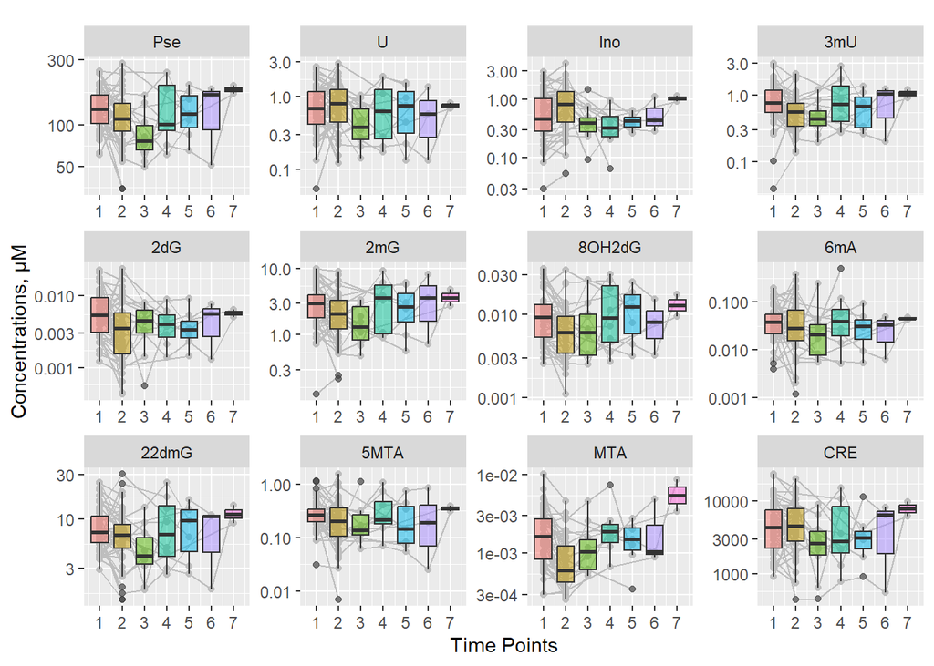

```r
new_labels = c("Pse", "U", "Ino", "3mU", "2dG", "2mG", "8OH2dG", "6mA","22dmG","5MTA","MTA", "CRE")
names(new_labels) <- c( "Pse","U","Ino","X3mU","X2dG","X2mG","X8OH2dG","X6mA","X22dmG","X5MTA","MTA","CRE")

p <- ggplot(subset(data_long, TimePoint<8))+
      geom_line(aes(x = TimePoint, y = DV, group = as.factor(ID), color="gray"))+
      geom_point(aes(x = TimePoint, y = DV, group = as.factor(ID), color="gray"))+
      geom_boxplot(aes(x = TimePoint, y = DV, fill=as.factor(TimePoint)),alpha=0.5) +
      scale_color_manual(values = "gray")+
        scale_y_continuous(trans='log10') +
        scale_x_continuous(breaks=seq(0,7,1)) +
      facet_wrap(.~as.factor(MET), scales="free", labeller = as_labeller(new_labels))+
      labs(title=element_blank(), x ="Time Points", y = "Concentrations, \u03BcM", color = "ID")+
      theme(legend.position="none")

print(p)
```

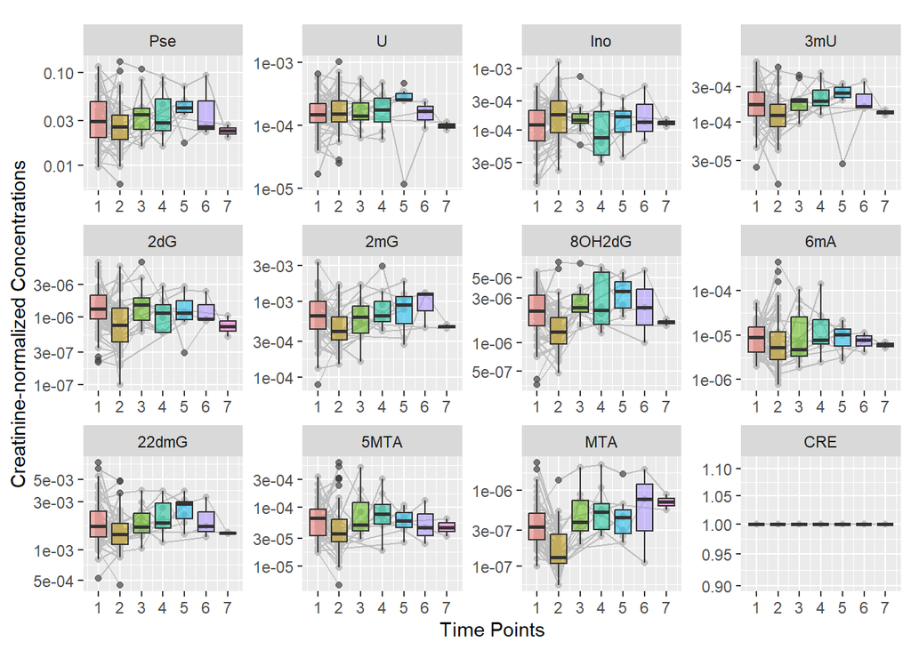

```r
ggsave("Manuscript/RawData.png", plot=p,  width = 15*1.4, height = 15, units = "cm", dpi=300)

p <- ggplot(subset(data_long, TimePoint<8))+
      geom_line(aes(x = TimePoint, y = DVCRE, group = as.factor(ID), color="gray"))+
      geom_point(aes(x = TimePoint, y = DVCRE, group = as.factor(ID), color="gray"))+
      geom_boxplot(aes(x = TimePoint, y = DVCRE, fill=as.factor(TimePoint)),alpha=0.5) +
      scale_color_manual(values = "gray")+
         scale_y_continuous(trans='log10') +
        scale_x_continuous(breaks=seq(0,7,1)) +
      facet_wrap(.~as.factor(MET), scales="free", labeller = as_labeller(new_labels))+
      labs(title=element_blank(), x ="Time Points", y = "Creatinine-normalized Concentrations", color = "ID")+
      theme(legend.position="none")

print(p)
```

## 3.2 Correlation plots:

There is a high correlation between metabolite concentrations. It is likely due to the variation in diuresis (urine dilution).

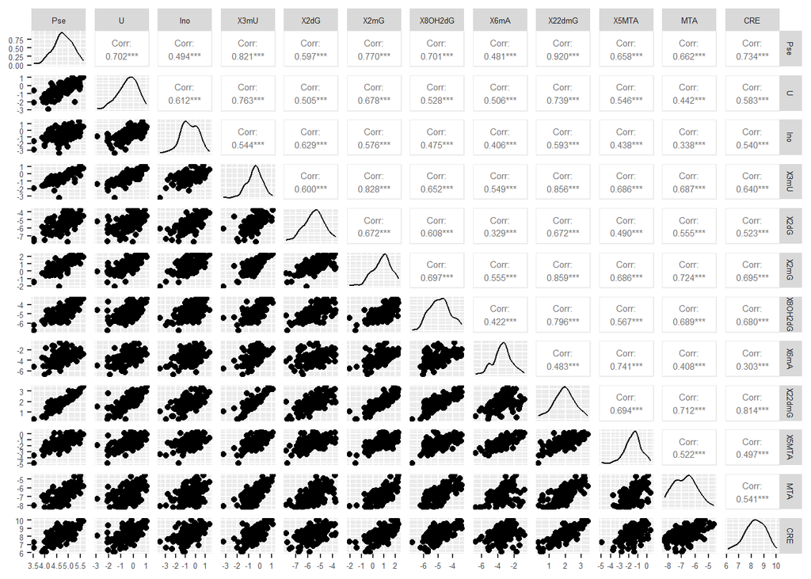

```r
data_wide_2 <- data_long %>%
  select(-c(CRE2, Sample, logDVCRE, DVCRE, DV)) %>%
  tidyr::pivot_wider(names_from = MET, values_from = logDV)

ggpairs(data_wide_2, columns = 7:(11+7),
        labeller = "label_parsed",
        upper = list(continuous = wrap("cor", size = 2)))+
theme(axis.text = element_text(size = 5))+
theme(strip.text.x = element_text(size = 5))+
theme(strip.text.y = element_text(size = 5))
```

```r
rm(data_wide_2)
```

# 4 Data analysis

The data was analyzed using [brms package](https://paul-buerkner.github.io/brms/). It fits the Bayesian generalized (non-)linear multivariate multilevel models using Stan. The default priors were used. The Time Points 3:7 were combined assuming no changes in urine concentrations for times > 2 weeks. The model assumes fixed effects of TimePoint, MET and the interaction of MET:TIMEPoint. The Sample and ID were modeled as random effects. The variance for between patient variability was different for each MET and correlated. The variance for within subject variability was also assumed to be different for each MET.

```r
data_long$TimePoint = as.factor(data_long$TimePoint)

levels(data_long$TimePoint) <- c(1,2,3,3,3,3,3)

data_long$Sample = as.factor(data_long$Sample)

# get_prior(bf(
#     logDV ~ TimePoint + MET + MET:TimePoint + (1+MET|ID) + (1|Sample),
#     sigma ~ MET),
#     family = student,
#     data = data_long)
```

Fit the model:

```r
fit <- brm(bf(
              logDV ~ TimePoint + MET + MET:TimePoint + (1+MET|ID) + (1|Sample),
              sigma ~ MET),
  family = student,
  data = data_long,
  chains = 4,
  cores = 4)

saveRDS(fit, file = "fit.RDS")
```

Load saved data.

```r
fit <- readRDS(file = "fit.RDS")
```

# 5 Posterior predictive check

The agreement between the data and simulation confirms that model predicts the data well.

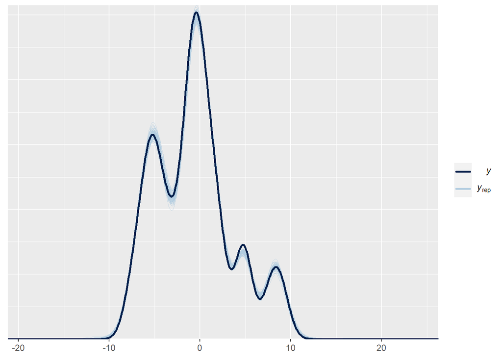

```r
pp_check(fit, ndraws = 100)
```

# 6 Summary of paramters

The marginal posterior distribution of each parameter. Posterior mean, standard error, 95% credible interval and Rhat statistic for each parameter of model.

```r
summary(fit)
```

```
 Family: student
  Links: mu = identity; sigma = log; nu = identity
Formula: logDV ~ TimePoint + MET + MET:TimePoint + (1 + MET | ID) + (1 | Sample)
         sigma ~ MET
   Data: data_long (Number of observations: 1594)
  Draws: 4 chains, each with iter = 2000; warmup = 1000; thin = 1;
         total post-warmup draws = 4000

Group-Level Effects:
~ID (Number of levels: 53)
                          Estimate Est.Error l-95% CI u-95% CI Rhat Bulk_ESS
sd(Intercept)                 0.25      0.06     0.14     0.36 1.01     1180
sd(METU)                      0.35      0.05     0.27     0.45 1.00     2138
sd(METIno)                    0.59      0.07     0.47     0.73 1.00     2190
sd(METX3mU)                   0.10      0.03     0.04     0.15 1.00     1106
sd(METX2dG)                   0.39      0.06     0.29     0.51 1.00     2740
sd(METX2mG)                   0.37      0.04     0.29     0.46 1.00     2360
sd(METX8OH2dG)                0.44      0.05     0.36     0.55 1.00     2217
sd(METX6mA)                   0.36      0.11     0.14     0.58 1.00     1447
sd(METX22dmG)                 0.14      0.02     0.09     0.19 1.00     1240
sd(METX5MTA)                  0.19      0.07     0.03     0.33 1.00     1477
sd(METMTA)                    0.42      0.05     0.33     0.54 1.00     2813
sd(METCRE)                    0.32      0.08     0.15     0.47 1.00     1014
cor(Intercept,METU)           0.23      0.19    -0.15     0.57 1.00     1068
cor(Intercept,METIno)         0.11      0.19    -0.25     0.47 1.00      841
cor(METU,METIno)              0.39      0.13     0.11     0.62 1.00     1522
cor(Intercept,METX3mU)        0.46      0.21     0.01     0.79 1.00     1985
cor(METU,METX3mU)             0.33      0.19    -0.10     0.65 1.00     2974
cor(METIno,METX3mU)          -0.01      0.19    -0.40     0.36 1.00     3995
cor(Intercept,METX2dG)        0.14      0.19    -0.23     0.50 1.00     1272
cor(METU,METX2dG)             0.26      0.16    -0.07     0.55 1.00     2740
cor(METIno,METX2dG)           0.70      0.11     0.45     0.87 1.00     3149
cor(METX3mU,METX2dG)          0.01      0.20    -0.40     0.40 1.00     2530
cor(Intercept,METX2mG)        0.43      0.17     0.07     0.73 1.00      936
cor(METU,METX2mG)             0.17      0.15    -0.12     0.44 1.00     2938
cor(METIno,METX2mG)           0.17      0.14    -0.11     0.43 1.00     2208
cor(METX3mU,METX2mG)          0.33      0.19    -0.10     0.66 1.00      973
cor(METX2dG,METX2mG)          0.32      0.15     0.02     0.60 1.00     2105
cor(Intercept,METX8OH2dG)     0.06      0.19    -0.32     0.43 1.00      680
cor(METU,METX8OH2dG)          0.04      0.15    -0.26     0.32 1.00     2342
```

[output cut: 225 more lines]

```
sigma_METX2mG             1772
sigma_METX8OH2dG          2674
sigma_METX6mA             2199
sigma_METX22dmG           2330
sigma_METX5MTA            1952
sigma_METMTA              2254
sigma_METCRE              2635

Family Specific Parameters:
   Estimate Est.Error l-95% CI u-95% CI Rhat Bulk_ESS Tail_ESS
nu     2.68      0.29     2.19     3.28 1.00     2815     3139

Draws were sampled using sampling(NUTS). For each parameter, Bulk_ESS
and Tail_ESS are effective sample size measures, and Rhat is the potential
scale reduction factor on split chains (at convergence, Rhat = 1).
```

# 7 Conditional effects

The following graphs display predicted concentrations for a typical subject and typical diuresis.

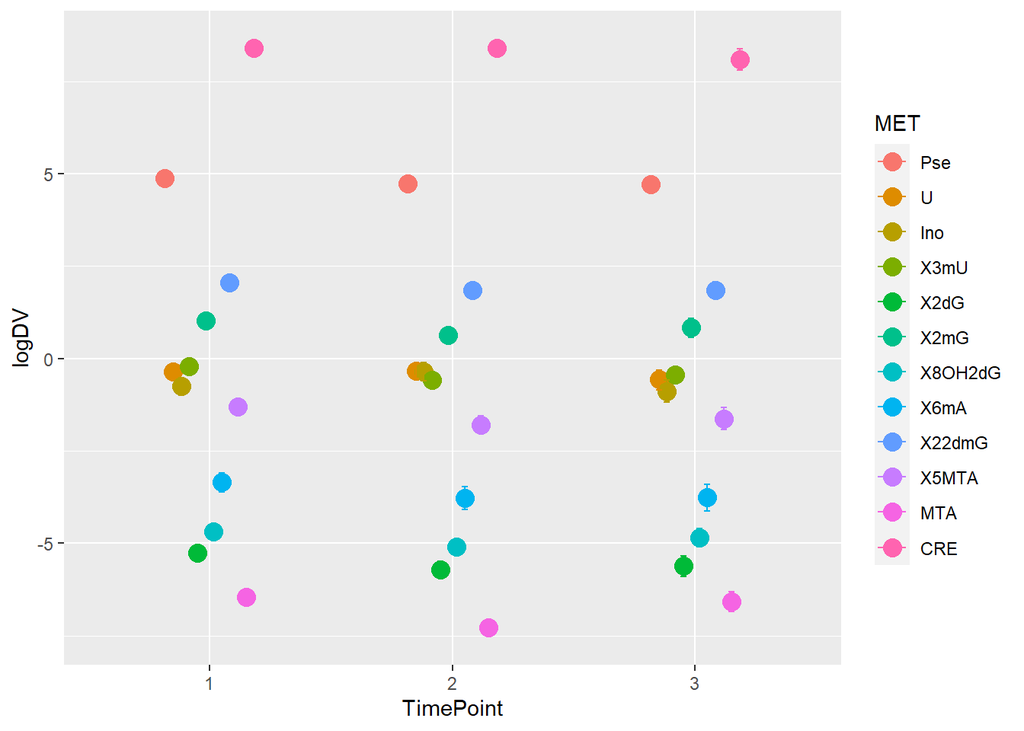

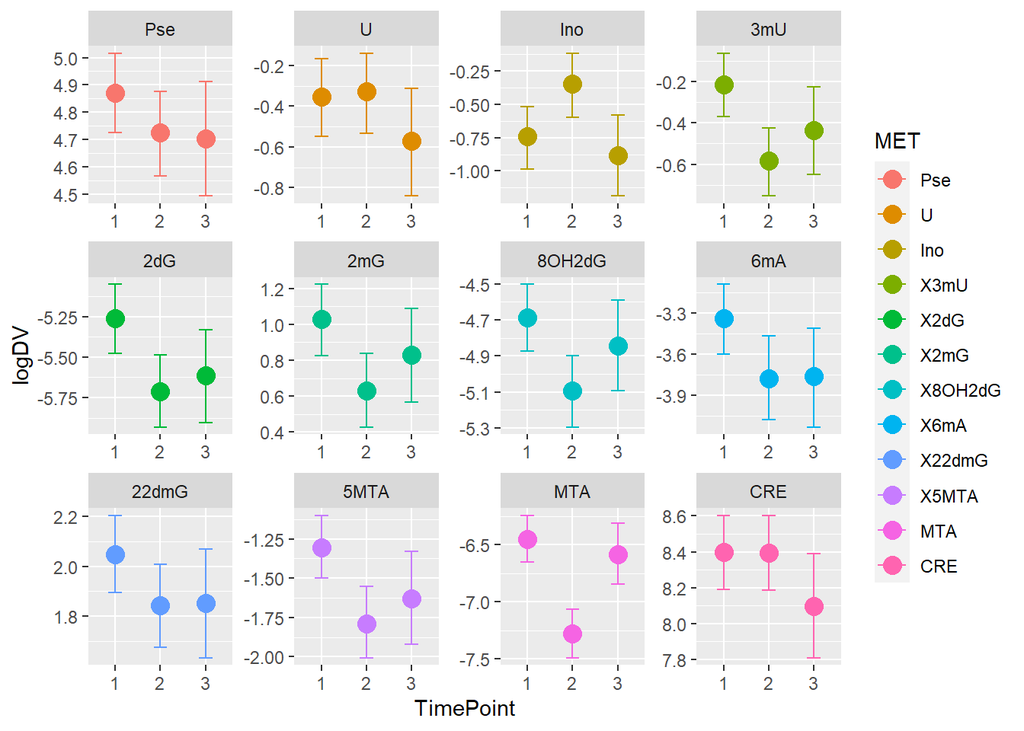

```r
plot(conditional_effects(fit, effects="TimePoint:MET"))[[1]]+
      facet_wrap(.~ MET, scales="free", labeller = as_labeller(new_labels))
```

# 8 Visualise estimated paramters

The effect of intervention is represented as a difference in an average MET concentration (for a typical subject and typical diuresis) between $TimePoint$ 2 (or 3) and $TimePoint$ 1. The solid line corresponds to no difference between TimePoints. The broken lines shows $\pm$ 0.223 difference corresponding to (0.8-1.25) fold change.

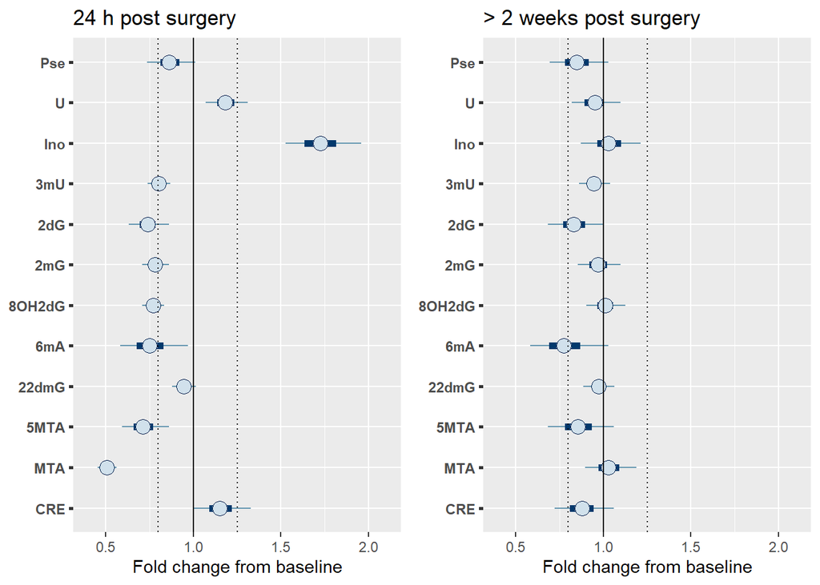

```r
new_labels = c("Pse", "U", "Ino", "3mU", "2dG", "2mG", "8OH2dG", "6mA","22dmG","5MTA","MTA", "CRE")


p1<-mcmc_plot(fit, variable = "^b_TimePoint2", regex = TRUE, transformation=exp)+
 geom_vline(xintercept = c(0.8,1.25), linetype = 3)+
  geom_vline(xintercept = c(1), linetype = 1) +
  xlim(0.4,2.1)+
  xlab("Fold change from baseline")+
  ggtitle("24 h post surgery")+
  scale_y_discrete(labels = rev(new_labels), limits = rev)

p2<-mcmc_plot(fit, variable = "^b_TimePoint3", regex = TRUE, transformation=exp)+
 geom_vline(xintercept = c(0.8,1.25), linetype = 3)+
geom_vline(xintercept = c(1), linetype = 1) +
  xlim(0.4,2.1)+
  xlab("Fold change from baseline")+
  ggtitle("> 2 weeks post surgery")+
  scale_y_discrete(labels = rev(new_labels), limits = rev)

p<-grid.arrange(p1,p2,ncol = 2)
```

```r
ggsave("Manuscript/Effects.png", plot=p,  width = 15*1.4, height = 15, units = "cm", dpi=300)
```

There are some large effect at $TimePoint=2$ that disappear at $TimePoints3$.

# 9 Hypothesis testing

The probability of the 0.8-fold decrease and 1.25-fold increase for each MET and TimePoint is:

```r
ans1<-hypothesis(fit, c("abs(TimePoint2)>0.223",
                        "abs(TimePoint2:METU)>0.223",
                        "abs(TimePoint2:METIno)>0.223",
                        "abs(TimePoint2:METX3mU)>0.223",
                        "abs(TimePoint2:METX2dG)>0.223",
                        "abs(TimePoint2:METX2mG)>0.223",
                        "abs(TimePoint2:METX8OH2dG)>0.223",
                        "abs(TimePoint2:METX22dmG)>0.223",
                        "abs(TimePoint2:METX5MTA)>0.223",
                        "abs(TimePoint2:METMTA)>0.223",
                        "abs(TimePoint2:METCRE)>0.223"
                        ))
ans2<-hypothesis(fit, c("abs(TimePoint3)>0.223",
                        "abs(TimePoint3:METU)>0.223",
                        "abs(TimePoint3:METIno)>0.223",
                        "abs(TimePoint3:METX3mU)>0.223",
                        "abs(TimePoint3:METX2dG)>0.223",
                        "abs(TimePoint3:METX2mG)>0.223",
                        "abs(TimePoint3:METX8OH2dG)>0.223",
                        "abs(TimePoint3:METX22dmG)>0.223",
                        "abs(TimePoint3:METX5MTA)>0.223",
                        "abs(TimePoint3:METMTA)>0.223",
                        "abs(TimePoint3:METCRE)>0.223"
                        ))


ans1$hypothesis$Hypothesis=c("abs(T2:PSU)>0.223",
                        "abs(T2:U)>0.223",
                        "abs(T2:Ino)>0.223",
                        "abs(T2:X3mU)>0.223",
                        "abs(T2:X2dG)>0.223",
                        "abs(T2:X2mG)>0.223",
                        "abs(T2:X8OH2dG)>0.223",
                        "abs(T2:X22dmG)>0.223",
                        "abs(T2:X5MTA)>0.223",
                        "abs(T2:MTA)>0.223",
                        "abs(T2:CRE)>0.223")
ans2$hypothesis$Hypothesis=c("abs(T3:PSU)>0.223",
                        "abs(T3:U)>0.223",
                        "abs(T3:Ino)>0.223",
                        "abs(T3:X3mU)>0.223",
                        "abs(T3:X2dG)>0.223",
                        "abs(T3:X2mG)>0.223",
                        "abs(T3:X8OH2dG)>0.223",
                        "abs(T3:X22dmG)>0.223",
                        "abs(T3:X5MTA)>0.223",
                        "abs(T3:MTA)>0.223",
                        "abs(T3:CRE)>0.223")
ans1
```

```
Hypothesis Tests for class b:
              Hypothesis Estimate Est.Error CI.Lower CI.Upper Evid.Ratio
1      abs(T2:PSU)>0.223    -0.07      0.09    -0.20     0.08       0.26
2        abs(T2:U)>0.223    -0.05      0.06    -0.16     0.05       0.23
3      abs(T2:Ino)>0.223     0.32      0.08     0.20     0.45    3999.00
4     abs(T2:X3mU)>0.223     0.00      0.05    -0.08     0.08       0.95
5     abs(T2:X2dG)>0.223     0.08      0.09    -0.07     0.24       4.25
6     abs(T2:X2mG)>0.223     0.03      0.06    -0.07     0.12       2.00
7  abs(T2:X8OH2dG)>0.223     0.04      0.05    -0.04     0.12       3.26
8   abs(T2:X22dmG)>0.223    -0.16      0.04    -0.22    -0.09       0.00
9    abs(T2:X5MTA)>0.223     0.11      0.11    -0.07     0.30       5.11
10     abs(T2:MTA)>0.223     0.46      0.07     0.35     0.57        Inf
11     abs(T2:CRE)>0.223    -0.08      0.08    -0.20     0.06       0.21
   Post.Prob Star
1       0.21
2       0.19
3       1.00    *
4       0.49
5       0.81
6       0.67
7       0.76
8       0.00
9       0.84
10      1.00    *
11      0.17
---
'CI': 90%-CI for one-sided and 95%-CI for two-sided hypotheses.
'*': For one-sided hypotheses, the posterior probability exceeds 95%;
for two-sided hypotheses, the value tested against lies outside the 95%-CI.
Posterior probabilities of point hypotheses assume equal prior probabilities.
```

```r
ans2
```

```
Hypothesis Tests for class b:
              Hypothesis Estimate Est.Error CI.Lower CI.Upper Evid.Ratio
1      abs(T3:PSU)>0.223    -0.05      0.11    -0.20     0.14       0.46
2        abs(T3:U)>0.223    -0.14      0.06    -0.22    -0.02       0.03
3      abs(T3:Ino)>0.223    -0.14      0.06    -0.22    -0.02       0.03
4     abs(T3:X3mU)>0.223    -0.16      0.05    -0.22    -0.07       0.00
5     abs(T3:X2dG)>0.223    -0.03      0.11    -0.20     0.16       0.60
6     abs(T3:X2mG)>0.223    -0.16      0.05    -0.22    -0.06       0.01
7  abs(T3:X8OH2dG)>0.223    -0.17      0.04    -0.22    -0.09       0.00
8   abs(T3:X22dmG)>0.223    -0.17      0.04    -0.22    -0.10       0.00
9    abs(T3:X5MTA)>0.223    -0.05      0.11    -0.21     0.16       0.44
10     abs(T3:MTA)>0.223    -0.15      0.06    -0.22    -0.05       0.02
11     abs(T3:CRE)>0.223    -0.08      0.10    -0.21     0.10       0.28
   Post.Prob Star
1       0.32
2       0.03
3       0.03
4       0.00
5       0.37
6       0.01
7       0.00
8       0.00
9       0.31
10      0.02
11      0.22
---
'CI': 90%-CI for one-sided and 95%-CI for two-sided hypotheses.
'*': For one-sided hypotheses, the posterior probability exceeds 95%;
for two-sided hypotheses, the value tested against lies outside the 95%-CI.
Posterior probabilities of point hypotheses assume equal prior probabilities.
```

```r
#plot(ans1)
```

There is a clear evidence the concentrations of Ino has increased and MTA has decreased 24 post surgery.

# 10 Variation in duresis

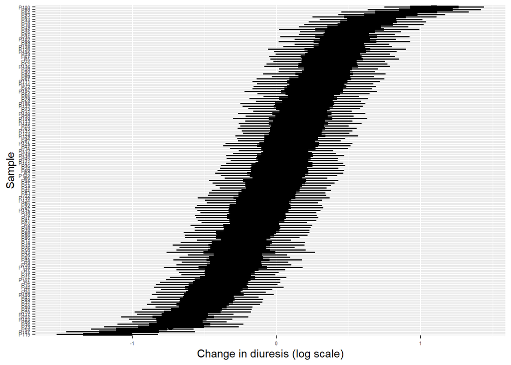

```r
fit %>%
    spread_draws(r_Sample[condition,]) %>%
    median_qi(condition_mean = r_Sample, .width = c(.95, 0.66))%>%
    ggplot(aes(y = reorder(condition,condition_mean), x = condition_mean, xmin = .lower, xmax = .upper)) +
    geom_pointinterval() +
    theme(axis.text = element_text(size = 5))+
    xlab("Change in diuresis (log scale)") +
    ylab("Sample")
```

# 11 Conclusions

- The lack of control group limits the possibility to answer whether there is an effect of cancer removal on urine concentration of nucleosides and deoxynucleosides. It is possible that the observed differences are related to the surgical procedure itself.
- MTA and Ino have the largest negative and positive effect at TimePoint2 (relative to Timepoint1). The effects are however temporary and return to pretreatment levels.